## Preparations

Load libraries and my custom functions.

```r
library(lattice)
library(latticeExtra)
source("~/projects/monoallelic-brain/src/import-data.R")
source("~/projects/monoallelic-brain/src/fit-glms.R")
```

Next:

1. import data
2. create subsets (conditioning)
3. fit models (logi.S, wnlm.R)
4. calculate confidence intervals (CI)

```r
E <- get.predictors() # default arguments
Y <- get.readcounts(gene.ids = gene.ids, count.thrs = 0)
# predictors for conditioning
s.p <- c("Institution", "Gender")
# exclude unweighed aggregates UA.8 and UA from fitting
Z <- Y[grep("^UA(.8)?$", names(Y), value = TRUE, invert = TRUE)]
M <- list(logi.S = l.l.do.all.fits.sset(s.p, Z, E, e.vars, "logi.S"),
          wnlm.R = l.l.do.all.fits.sset(s.p, Z, E, e.vars, "wnlm.R"))
# regression coefficients: estimates and CI at 99 % level
Betas <- lapply(M, function(l3m) {
    df <- do.call(make.groups,
                  lapply(l3m,
                         function(l2m)
                             do.call(make.groups,
                                     lapply(l2m,
                                            get.estimate.CI, conf.lev = 0.99))))
    names(df)[-(1:5)] <- c("Level", "Cond.Var")
    return(df)
})
```

## Results

In the following plots the effect of 5 conditions (*MSSM*, …, *Female*) is explored on the inferred \(\beta_\mathrm{age}\). *All* denotes the full set of observations (no conditioning), as done before. Note the following

- two types of regression model were fitted
  - *logi.S*: logistic model fitted to untransformed \(S\)
  - *wnlm.R*: weighted normal linear model fitted to rank-transformed \(S\)
- the colored bars show confidence intervals (CI) for \(\beta_\mathrm{age}\)
  - some CI are missing (could not be calculated because of too little variance in the response)
- the vertical red line spanning each graph is at \(\beta = 0\), so when a CI does not “cross” that line we can conclude that the effect of *Age* is significant on the response (\(p < 0.01\))
- the vertical notch “I” inside the bars marks the least square estimate \(\hat{\beta}_\mathrm{age}\)
- the individual displays (each corresponding to a given gene or aggregate dataset across genes) are scaled differently to emphasize the effects of conditioning.
- the fit for TMEM261P1 did not converge under logi.S so the results are missing; for consistency TMEM261P1 is excluded for wnlm.R as well

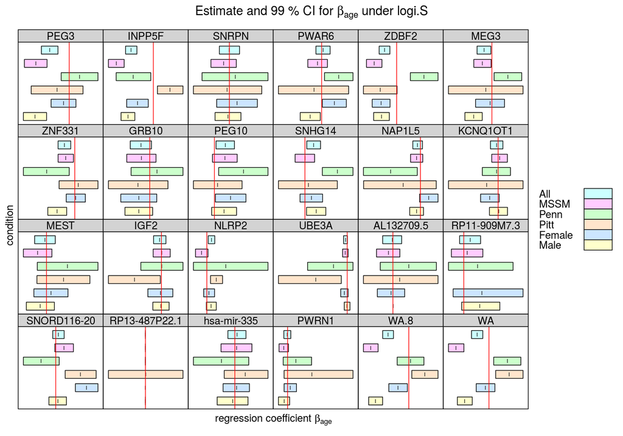

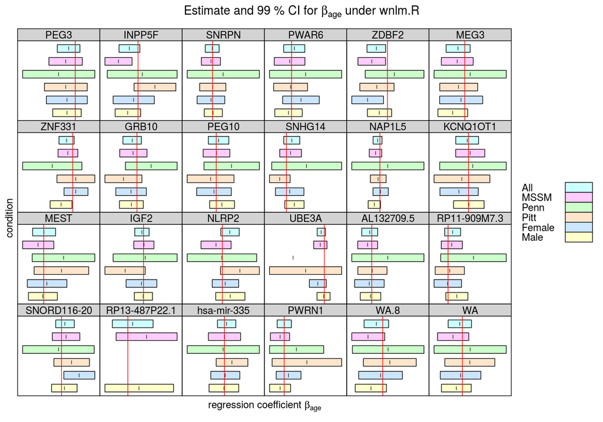

## Conclusion

The main results and their interpretation can be summarized as follows:

- For several genes conditioning qualitatively changes the effect of *Age* on the response in a pattern that is similar under logi.S and wnlm.R. This suggests that some assumption(s) that is shared by both models is violated. The most obvious shared assumption is **linearity**. In other words, (generalized) linear models fail to capture the complex **dependency structure** that relates predictors to each other and to the response. Bayesian networks provide the most general framework suitable to deal with such dependency structure. A less general alternative is using (generalized) linear models extended with interaction terms.
- Under wnlm.R conditioning has weaker effect than under logi.S. This suggests that while logi.S is more powerful than wnlm.R (as expected from a theory-based weighting scheme) it is also less robust for reasons extraneous to nonlinearity. A logi.S-specific assumption is the sigmoidal **link function** (logistic function), whose inflection point is well beyond several hundred years for all genes and thus far beyond the range of *Age* data. This need for extrapolation makes logi.S extremely sensitive to **overfitting** due to reduction of the number of observations, which is stronger in the case of conditioning on *Penn* or *Pitt* than on *MSSM*, which alone provided \(\approx 55 \%\) of the observations. Consistent with this, conditioning on *MSSM* has the smallest effect. Another potential limitation of the logi.S model is the assumption that the *error distribution* is binomial (see discussion on overdispersion in the [voom paper](http://genomebiology.biomedcentral.com/articles/10.1186/gb-2014-15-2-r29)).
- Conditioning on the *Penn* or *Pitt* levels of *Institution* has in general larger effect than that on levels of *Gender*. This is consistent with the stronger association of *Age* to *Institution* than to *Gender*, found previously.

### How to deal with the present limitations?

Suggested alternatives, roughly in increasing model complexity

1. under the present models interpret the results more carefully
   - pro: no further analysis required
   - con: the conclusion that age has effect on allelic imbalance remains weakly established
2. linear modeling with voom/limma
   - pro: (1) allows fitting normal linear models on suitably transformed \(S\) with the advantage of more power than wnlm.R and (expectedly) more robustness to nonlinearity than logi.S; also (2), voom/limma uses a more detailed form of data, at the level of SNPs instead of genes, potentially using available information more efficiently; (3) mature `R` packages are available
   - con: substantial additional analysis, including the recovery of the full (i.e. SNP-based) read count data
3. extend present models with interaction terms such as that between *Age* and *Institution*
   - pro: can be performed on the readily available gene-based read count data
   - con: including too few interactions may not suffice correcting for nonlinearity whereas even a few interaction terms greatly increase the number of parameters, resulting in overfitting, therefore this approach might need to be combined with formal model selection implemented in for instance the `stats` package of `R` (see `add1` and `step` functions) to find the best balance between model fit and parsimony
4. use Bayesian networks (BN)
   - pro: even the most complex dependency structure can be captured by a BN
   - con: many details of statistics and software implementation must be worked out